# Data Exploration for Car Insurance Data

Mick Cooney mcooney@agrippadataconsulting.com

2018-11-27

This workbook was created using the ‘dataexpks’ template:

https://github.com/DublinLearningGroup/dataexpks

# 1 Introduction

This workbook performs the basic data exploration of the dataset.

```r
dataexp_level_exclusion_threshold <- 100

dataexp_cat_level_count <- 40
dataexp_hist_bins_count <- 50
```

# 2 Load Data

First we load the dataset.

```r
### _TEMPLATE_
### Data is loaded into dataset rawdata_tbl here

### We may wish to set column typs
data_col_types <- cols(
    PolicyID = col_character()
   ,ClaimNb  = col_integer()
   #  VAR1 = col_character()
   # ,VAR2 = col_date()
   # ,VAR3 = col_number()
)

### Data is loaded into dataset rawdata_tbl here
rawdata_tbl <- read_csv('data/carinsurance_frequency.csv'
                       ,locale    = locale()
                       ,col_types = data_col_types
                       ,progress  = FALSE
                       )

glimpse(rawdata_tbl)
```

```
## Observations: 413,169
## Variables: 10
## $ PolicyID  <chr> "1", "2", "3", "4", "5", "6", "7", "8", "9", "10", "11", "12", "13"...
## $ ClaimNb   <int> 0, 0, 0, 0, 0, 0, 0, 0, 0, 0, 0, 0, 0, 0, 0, 0, 0, 0, 0, 0, 0, 0, 0...
## $ Exposure  <dbl> 0.09, 0.84, 0.52, 0.45, 0.15, 0.75, 0.81, 0.05, 0.76, 0.34, 0.10, 0...
## $ Power     <chr> "g", "g", "f", "f", "g", "g", "d", "d", "d", "i", "f", "f", "e", "e...
## $ CarAge    <dbl> 0, 0, 2, 2, 0, 0, 1, 0, 9, 0, 2, 2, 0, 0, 0, 0, 0, 0, 0, 0, 0, 0, 8...
## $ DriverAge <dbl> 46, 46, 38, 38, 41, 41, 27, 27, 23, 44, 32, 32, 33, 33, 33, 54, 69,...
## $ Brand     <chr> "Japanese (except Nissan) or Korean", "Japanese (except Nissan) or ...
## $ Gas       <chr> "Diesel", "Diesel", "Regular", "Regular", "Diesel", "Diesel", "Regu...
## $ Region    <chr> "R72", "R72", "R31", "R31", "R52", "R52", "R72", "R72", "R31", "R11...
## $ Density   <dbl> 76, 76, 3003, 3003, 60, 60, 695, 695, 7887, 27000, 23, 23, 1746, 17...
```

## 2.1 Perform Quick Data Cleaning

```r
### _TEMPLATE_
### Do simple datatype transforms and save output in data_tbl
data_tbl <- rawdata_tbl

names(data_tbl) <- rawdata_tbl %>% names %>% clean_names

glimpse(data_tbl)
```

```
## Observations: 413,169
## Variables: 10
## $ policy_id  <chr> "1", "2", "3", "4", "5", "6", "7", "8", "9", "10", "11", "12", "13...
## $ claim_nb   <int> 0, 0, 0, 0, 0, 0, 0, 0, 0, 0, 0, 0, 0, 0, 0, 0, 0, 0, 0, 0, 0, 0, ...
## $ exposure   <dbl> 0.09, 0.84, 0.52, 0.45, 0.15, 0.75, 0.81, 0.05, 0.76, 0.34, 0.10, ...
## $ power      <chr> "g", "g", "f", "f", "g", "g", "d", "d", "d", "i", "f", "f", "e", "...
## $ car_age    <dbl> 0, 0, 2, 2, 0, 0, 1, 0, 9, 0, 2, 2, 0, 0, 0, 0, 0, 0, 0, 0, 0, 0, ...
## $ driver_age <dbl> 46, 46, 38, 38, 41, 41, 27, 27, 23, 44, 32, 32, 33, 33, 33, 54, 69...
## $ brand      <chr> "Japanese (except Nissan) or Korean", "Japanese (except Nissan) or...
## $ gas        <chr> "Diesel", "Diesel", "Regular", "Regular", "Diesel", "Diesel", "Reg...
## $ region     <chr> "R72", "R72", "R31", "R31", "R52", "R52", "R72", "R72", "R31", "R1...
## $ density    <dbl> 76, 76, 3003, 3003, 60, 60, 695, 695, 7887, 27000, 23, 23, 1746, 1...
```

## 2.2 Create Derived Variables

We now create derived features useful for modelling. These values are new variables calculated from existing variables in the data.

```r
# data_tbl <- data_tbl %>%
#     mutate()
```

## 2.3 Check Missing Values

Before we do anything with the data, we first check for missing values in the dataset. In some cases, missing data is coded by a special character rather than as a blank, so we first correct for this.

```r
### _TEMPLATE_
### ADD CODE TO CORRECT FOR DATA ENCODING HERE
```

With missing data properly encoded, we now visualise the missing data in a number of different ways.

### 2.3.1 Univariate Missing Data

We first examine a simple univariate count of all the missing data:

```r
row_count <- data_tbl %>% nrow

missing_univariate_tbl <- data_tbl %>%
    summarise_all(funs(sum(is.na(.)))) %>%
    gather('variable','missing_count') %>%
    mutate(missing_prop = missing_count / row_count)

ggplot(missing_univariate_tbl) +
    geom_bar(aes(x = fct_reorder(variable, -missing_prop), weight = missing_prop)) +
    scale_y_continuous(labels = comma) +
    xlab("Variable") +
    ylab("Missing Value Proportion") +
    theme(axis.text.x = element_text(angle = 90))
```

[output not shown]

We remove all variables where all of the entries are missing

```r
remove_vars <- missing_univariate_tbl %>%
    filter(missing_count == row_count) %>%
    .[['variable']]

lessmiss_data_tbl <- data_tbl %>%
    dplyr::select(-one_of(remove_vars))
```

With these columns removed, we repeat the exercise.

```r
missing_univariate_tbl <- lessmiss_data_tbl %>%
    summarise_all(funs(sum(is.na(.)))) %>%
    gather('variable','missing_count') %>%
    mutate(missing_prop = missing_count / row_count)

ggplot(missing_univariate_tbl) +
    geom_bar(aes(x = fct_reorder(variable, -missing_prop), weight = missing_prop)) +
    scale_y_continuous(labels = comma) +
    xlab("Variable") +
    ylab("Missing Value Proportion") +
    theme(axis.text.x = element_text(angle = 90))
```

[output not shown]

```r
missing_univariate_top_tbl <- missing_univariate_tbl %>%
    arrange(desc(missing_count)) %>%
    top_n(n = 50, wt = missing_count)

ggplot(missing_univariate_top_tbl) +
    geom_bar(aes(x = fct_reorder(variable, -missing_prop), weight = missing_prop)) +
    scale_y_continuous(labels = comma) +
    xlab("Variable") +
    ylab("Missing Value Proportion") +
    theme(axis.text.x = element_text(angle = 90))
```

[output not shown]

### 2.3.2 Multivariate Missing Data

It is useful to get an idea of what combinations of variables tend to have variables with missing values simultaneously, so to construct a visualisation for this we create a count of all the times given combinations of variables have missing values, producing a heat map for these combination counts.

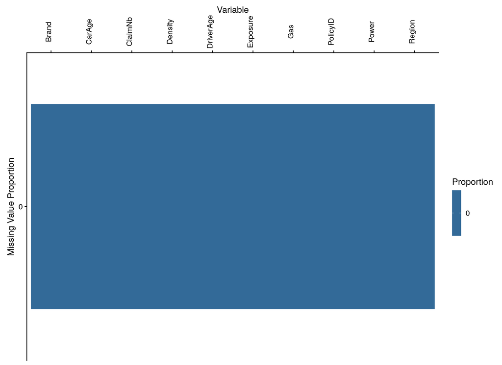

```r
missing_plot_tbl <- rawdata_tbl %>%
    mutate_all(funs(is.na)) %>%
    mutate_all(funs(as.numeric)) %>%
    mutate(label = do.call(paste0, (.))) %>%
    group_by(label) %>%
    summarise_all(funs(sum)) %>%
    arrange(desc(label)) %>%
    dplyr::select(-label) %>%
    mutate(rowid = do.call(pmax, (.))) %>%
    gather('col','count', -rowid) %>%
    mutate(Proportion = count / row_count
          ,rowid      = round(rowid / row_count, 4)
    )

ggplot(missing_plot_tbl) +
    geom_tile(aes(x = col, y = as.factor(rowid), fill = Proportion), height = 0.8) +
    scale_fill_continuous(labels = comma) +
    scale_x_discrete(position = 'top') +
    xlab("Variable") +
    ylab("Missing Value Proportion") +
    theme(axis.text.x = element_text(angle = 90))
```

This visualisation takes a little explaining.

Each row represents a combination of variables with simultaneous missing values. For each row in the graphic, the coloured entries show which particular variables are missing in that combination. The proportion of rows with that combination is displayed in both the label for the row and the colouring for the cells in the row.

## 2.4 Inspect High-level-count Categorical Variables

With the raw data loaded up we now remove obvious unique or near-unique variables that are not amenable to basic exploration and plotting.

```r
coltype_lst <- create_coltype_list(data_tbl)

if(!is.null(coltype_lst$split$discrete)) {
    catvar_valuecount_tbl <- data_tbl %>%
        summarise_at(coltype_lst$split$discrete
                    ,function(x) length(unique(x))) %>%
        gather('var_name', 'level_count') %>%
        arrange(-level_count)

    print(catvar_valuecount_tbl)

    row_count <- nrow(data_tbl)

    cat(paste0("Dataset has ", row_count, " rows\n"))
} else {
    cat('No categorical variables in dataset\n')
}
```

```
## # A tibble: 5 x 2
##   var_name  level_count
##   <chr>           <int>
## 1 policy_id      413169
## 2 power              12
## 3 region             10
## 4 brand               7
## 5 gas                 2
## Dataset has 413169 rows
```

Now that we a table of the counts of all the categorical variables we can automatically exclude unique variables from the exploration, as the level count will match the row count.

```r
if(!is.null(coltype_lst$split$discrete)) {
    unique_vars <- catvar_valuecount_tbl %>%
        filter(level_count == row_count) %>%
        .[["var_name"]]

    print(unique_vars)

    explore_data_tbl <- data_tbl %>%
        dplyr::select(-one_of(unique_vars))
} else {
    explore_data_tbl <- data_tbl
}
```

```
## [1] "policy_id"
```

Having removed the unique identifier variables from the dataset, we may also wish to exclude categoricals with high level counts also, so we create a vector of those variable names.

```r
if(!is.null(coltype_lst$split$discrete)) {
    highcount_vars <- catvar_valuecount_tbl %>%
        filter(level_count >= dataexp_level_exclusion_threshold
              ,level_count < row_count) %>%
        .[["var_name"]]

    cat(paste0(highcount_vars, collapse = ', '))
} else {
    highcount_vars <- c()
}
```

We now can continue doing some basic exploration of the data. We may also choose to remove some extra columns from the dataset.

```r
### You may want to comment out these next few lines to customise which
### categoricals are kept in the exploration.
drop_vars <- c(highcount_vars)

if(length(drop_vars) > 0) {
    explore_data_tbl <- explore_data_tbl %>%
        dplyr::select(-one_of(drop_vars))

    cat(paste0(drop_vars, collapse = ', '))
}
```

## 2.5 Write Loaded Data to Disk

```r
#data_tbl %>% write_csv(path = 'data/loaded_data.csv')
```

# 3 Univariate Data Exploration

Now that we have loaded the data we can prepare it for some basic data exploration. We first exclude the variables that are unique identifiers or similar, and tehen split the remaining variables out into various categories to help with the systematic data exploration.

```r
coltype_lst <- create_coltype_list(explore_data_tbl)

print(coltype_lst)
```

```
## $split
## $split$continuous
## [1] "claim_nb"   "exposure"   "car_age"    "driver_age" "density"
##
## $split$discrete
## [1] "power"  "brand"  "gas"    "region"
##
##
## $columns
##     claim_nb     exposure        power      car_age   driver_age        brand
## "continuous" "continuous"   "discrete" "continuous" "continuous"   "discrete"
##          gas       region      density
##   "discrete"   "discrete" "continuous"
```

## 3.1 Logical Variables

Logical variables only take two values: TRUE or FALSE. It is useful to see missing data as well though, so we also plot the count of those.

```r
logical_vars <- coltype_lst$split$logical

for(plot_varname in logical_vars) {
    cat("--\n")
    cat(paste0(plot_varname, '\n'))

    na_count <- explore_data_tbl %>% .[[plot_varname]] %>% is.na %>% sum

    explore_plot <- ggplot(explore_data_tbl) +
        geom_bar(aes_string(x = plot_varname)) +
        xlab(plot_varname) +
        ylab("Count") +
        scale_y_continuous(labels = comma) +
        ggtitle(paste0('Barplot of Counts for Variable: ', plot_varname
                      ,' (', na_count, ' missing values)')) +
        theme(axis.text.x = element_text(angle = 90, vjust = 0.5))

    plot(explore_plot)
}
```

## 3.2 Numeric Variables

Numeric variables are usually continuous in nature, though we also have integer data.

```
## --
## claim_nb
##    Min. 1st Qu.  Median    Mean 3rd Qu.    Max.
##  0.0000  0.0000  0.0000  0.0392  0.0000  4.0000
```

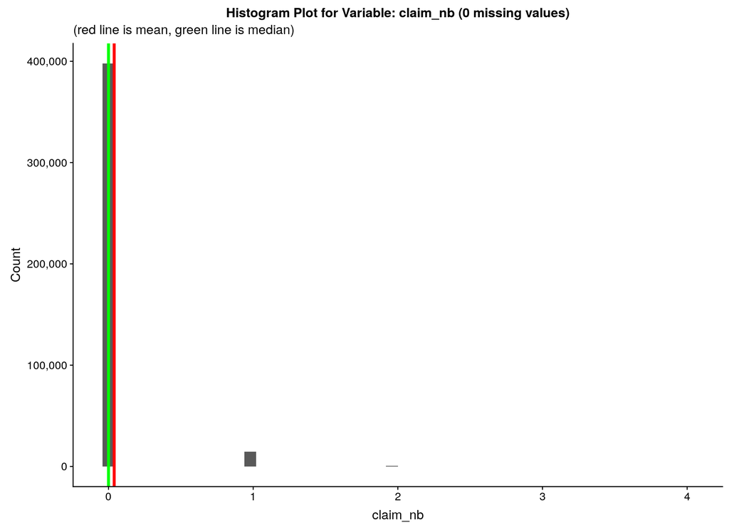

```
## --
## exposure
##    Min. 1st Qu.  Median    Mean 3rd Qu.    Max.
## 0.00273 0.20000 0.54000 0.56109 1.00000 1.99000
```

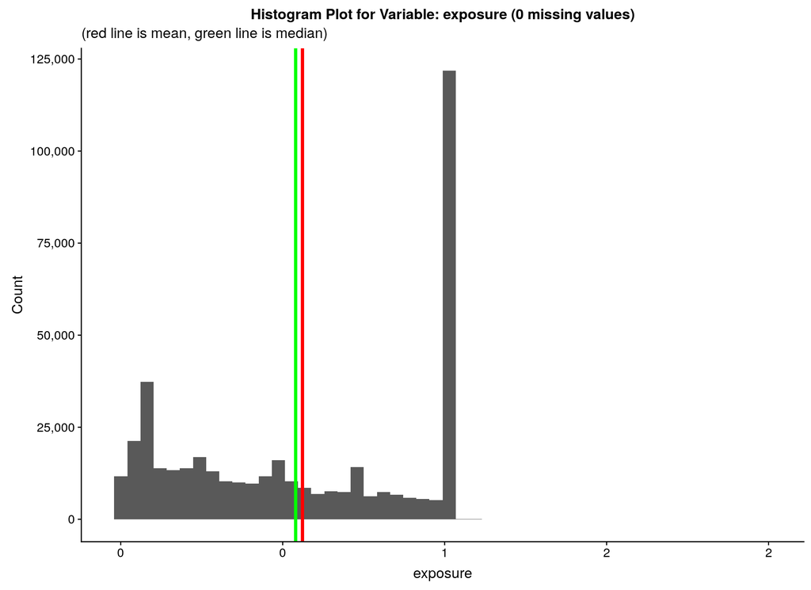

```
## --
## car_age
##    Min. 1st Qu.  Median    Mean 3rd Qu.    Max.
##    0.00    3.00    7.00    7.53   12.00  100.00
```

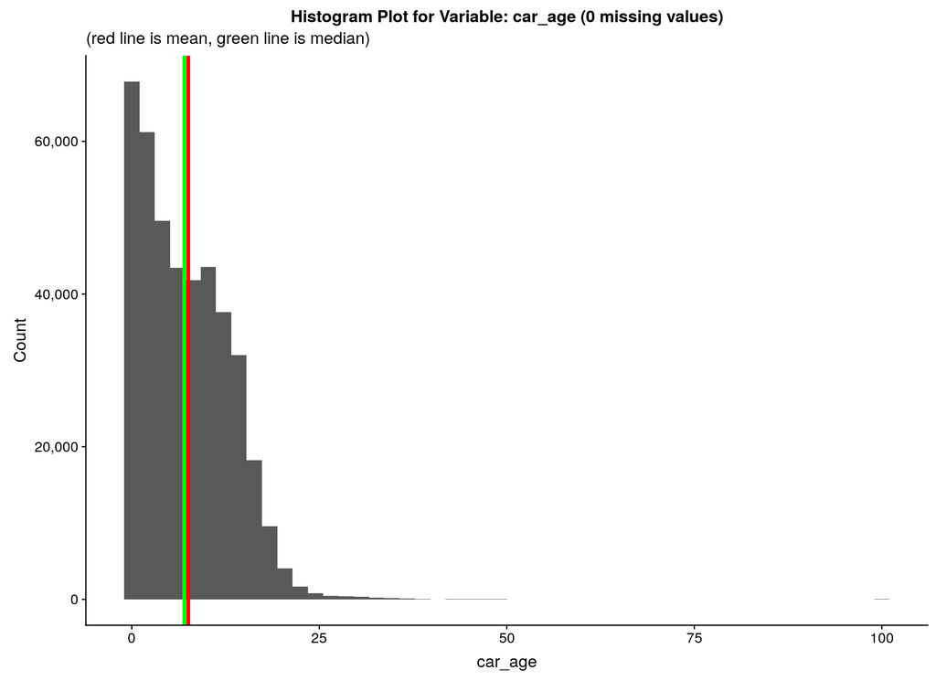

```
## --
## driver_age
##    Min. 1st Qu.  Median    Mean 3rd Qu.    Max.
##    18.0    34.0    44.0    45.3    54.0    99.0
```

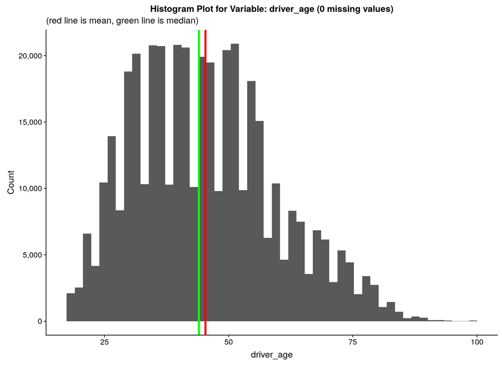

```
## --
## density
##    Min. 1st Qu.  Median    Mean 3rd Qu.    Max.
##       2      67     287    1985    1410   27000
```

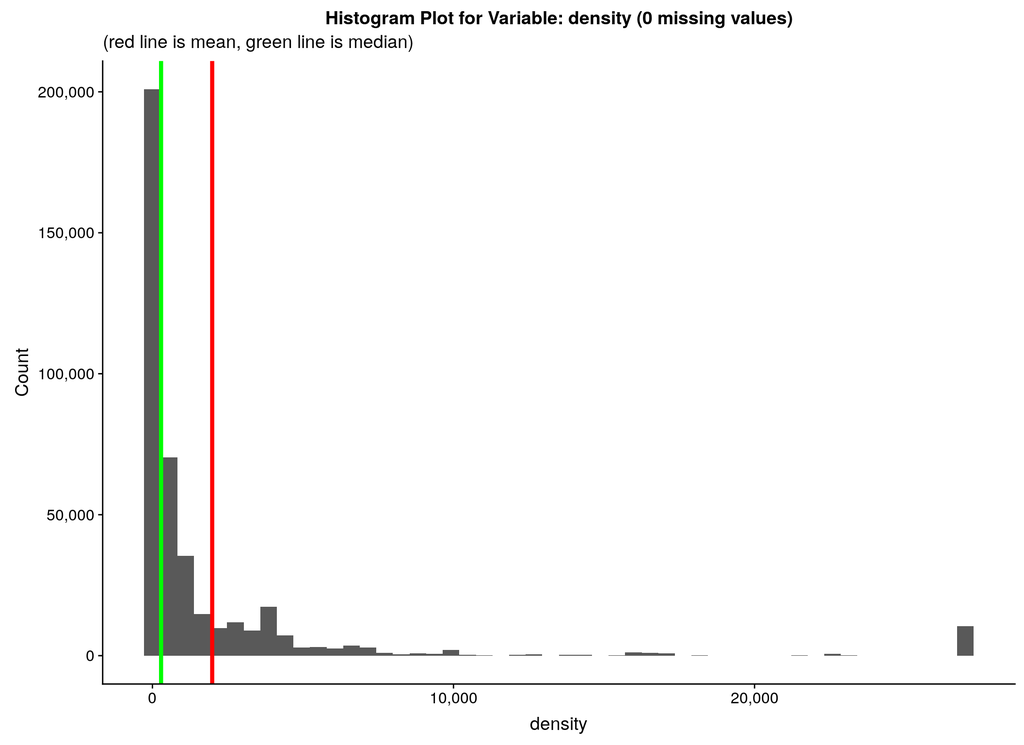

```r
numeric_vars <- coltype_lst$split$continuous

for(plot_varname in numeric_vars) {
    cat("--\n")
    cat(paste0(plot_varname, '\n'))

    plot_var <- explore_data_tbl %>% .[[plot_varname]]
    na_count <- plot_var %>% is.na %>% sum

    plot_var %>% summary %>% print

    explore_plot <- ggplot(explore_data_tbl) +
        geom_histogram(aes_string(x = plot_varname), bins = dataexp_hist_bins_count) +
        geom_vline(xintercept = mean  (plot_var, na.rm = TRUE), colour = 'red',   size = 1.5) +
        geom_vline(xintercept = median(plot_var, na.rm = TRUE), colour = 'green', size = 1.5) +
        xlab(plot_varname) +
        ylab("Count") +
        scale_x_continuous(labels = comma) +
        scale_y_continuous(labels = comma) +
        ggtitle(paste0('Histogram Plot for Variable: ', plot_varname
                      ,' (', na_count, ' missing values)')
               ,subtitle = '(red line is mean, green line is median)')

    print(explore_plot)
}
```

## 3.3 Categorical Variables

Categorical variables only have values from a limited, and usually fixed, number of possible values

```
## --
## power
```

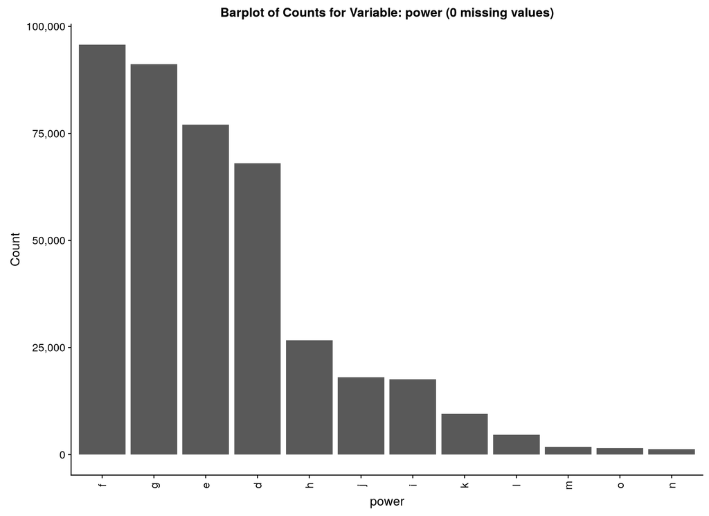

```
## --
## brand
```

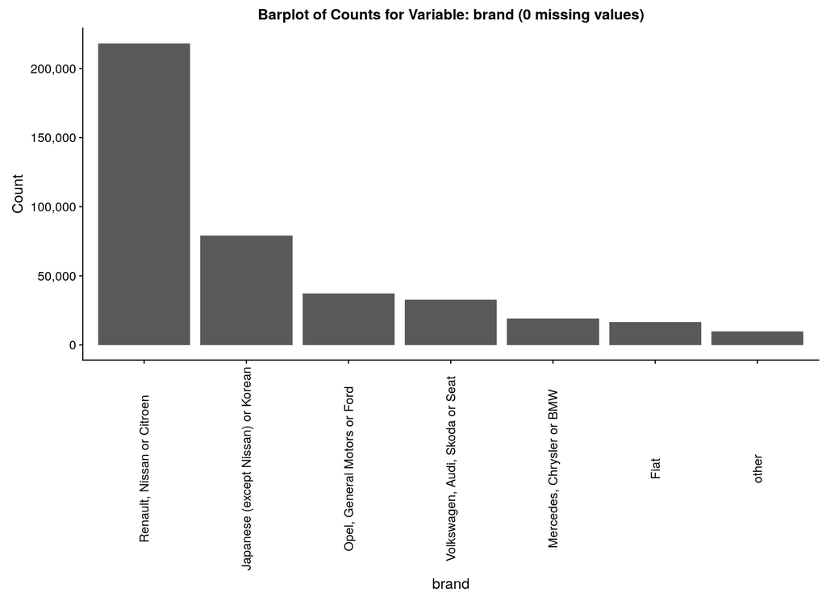

```
## --
## gas
```

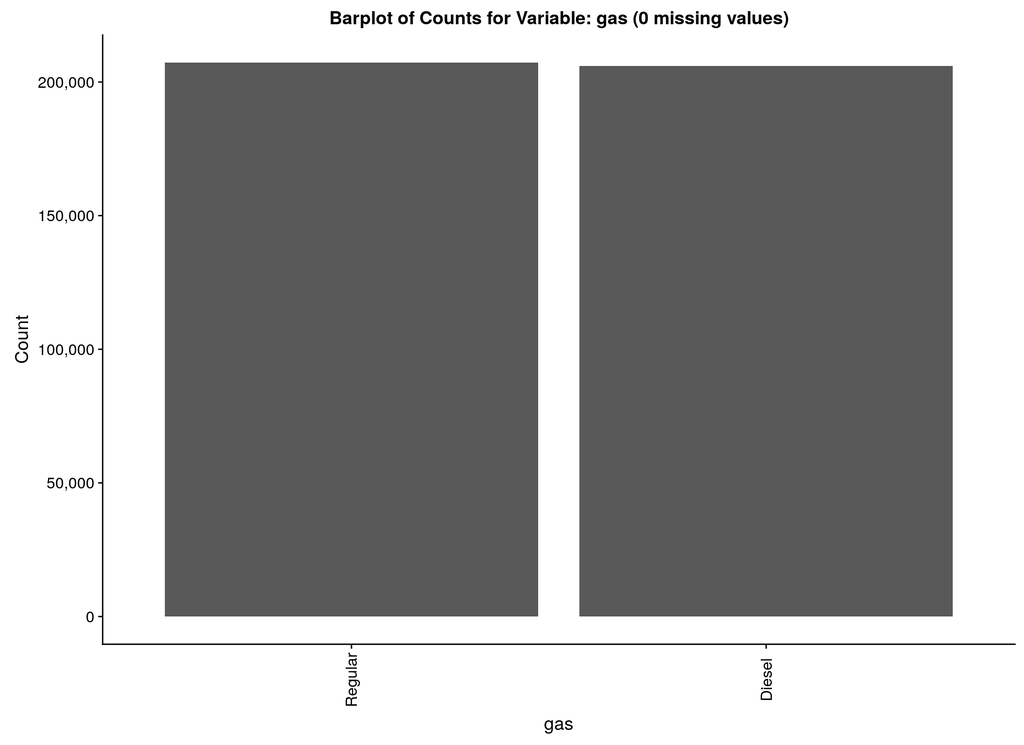

```
## --
## region
```

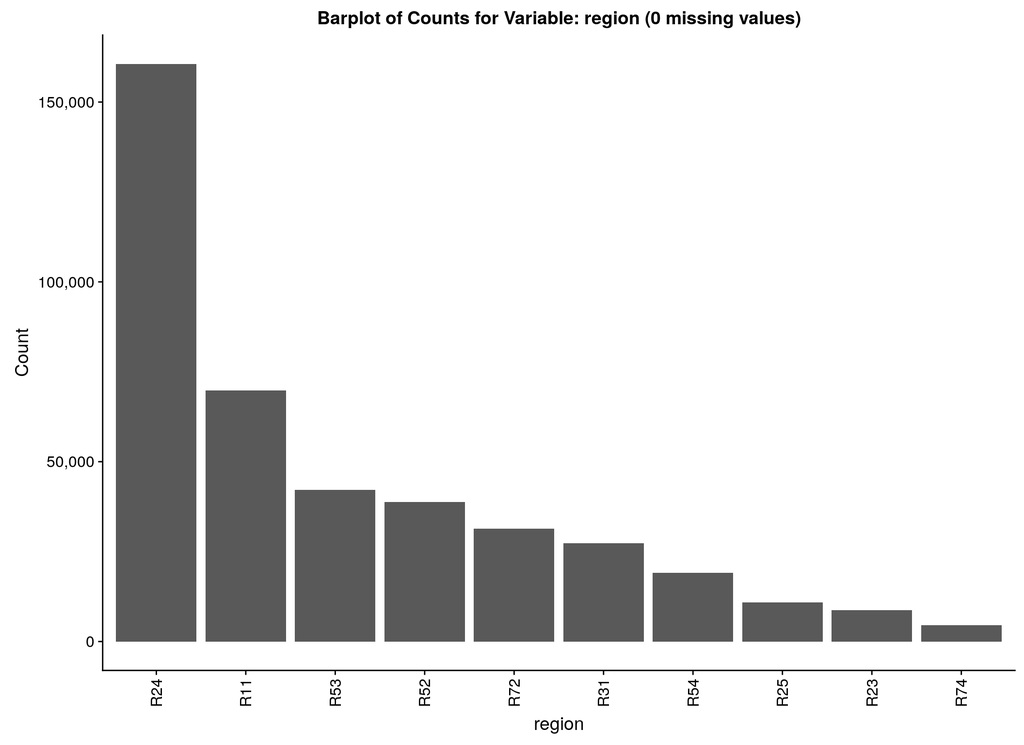

```r
categorical_vars <- coltype_lst$split$discrete

for(plot_varname in categorical_vars) {
    cat("--\n")
    cat(paste0(plot_varname, '\n'))

    na_count <- explore_data_tbl %>% .[[plot_varname]] %>% is.na %>% sum

    plot_tbl <- explore_data_tbl %>%
        .[[plot_varname]] %>%
        as.character %>%
        fct_lump(n = dataexp_cat_level_count) %>%
        fct_count

    explore_plot <- ggplot(plot_tbl) +
        geom_bar(aes(x = fct_reorder(f, -n), weight = n)) +
        xlab(plot_varname) +
        ylab("Count") +
        scale_y_continuous(labels = comma) +
        ggtitle(paste0('Barplot of Counts for Variable: ', plot_varname
                      ,' (', na_count, ' missing values)')) +
        theme(axis.text.x = element_text(angle = 90, vjust = 0.5))

    plot(explore_plot)
}
```

## 3.4 Date/Time Variables

Date/Time variables represent calendar or time-based data should as time of the day, a date, or a timestamp.

```r
datetime_vars <- coltype_lst$split$datetime

for(plot_varname in datetime_vars) {
    cat("--\n")
    cat(paste0(plot_varname, '\n'))

    plot_var <- explore_data_tbl %>% .[[plot_varname]]
    na_count <- plot_var %>% is.na %>% sum

    plot_var %>% summary %>% print

    explore_plot <- ggplot(explore_data_tbl) +
        geom_histogram(aes_string(x = plot_varname), bins = dataexp_hist_bins_count) +
        xlab(plot_varname) +
        ylab("Count") +
        scale_y_continuous(labels = comma) +
        ggtitle(paste0('Barplot of Dates/Times in Variable: ', plot_varname
                      ,' (', na_count, ' missing values)'))

    plot(explore_plot)
}
```

# 4 Bivariate Data Exploration

We now move on to looking at bivariate plots of the data set.

## 4.1 Facet Plots on Variables

We want to look at how the variables split on the logical variables as this is a very natural way to observe the data.

```r
### _TEMPLATE_
facet_varname <- 'gas'
#facet_varname   <- coltype_lst$split$discrete[1]


facet_count_max <- 3
facet_formula   <- formula(paste0("~ as.factor(", facet_varname, ")"))
```

### 4.1.1 Logical Variables

For logical variables we facet on barplots of the levels, comparing TRUE, FALSE and missing data.

```r
logical_vars <- logical_vars[!logical_vars %in% facet_varname]

for(plot_varname in logical_vars) {
    cat("--\n")
    cat(paste0(plot_varname, '\n'))

    filter_formula <- formula(paste0("~ !is.na(", plot_varname, ")"))

    plot_tbl <- data_tbl %>% filter_(filter_formula)

    facet_count <- plot_tbl %>%
        .[[facet_varname]] %>%
        unique %>%
        length %>%
        min(facet_count_max)

    explore_plot <- ggplot(plot_tbl) +
        geom_bar(aes_string(x = plot_varname)) +
        facet_wrap(facet_formula, scales = 'free') +
        xlab(plot_varname) +
        ylab("Count") +
        scale_y_continuous(labels = comma) +
        ggtitle(paste0(facet_varname, '-Faceted Barplots for Variable: ', plot_varname)) +
        theme(axis.text.x = element_text(angle = 90, vjust = 0.5))

    plot(explore_plot)
}
```

### 4.1.2 Numeric Variables

For numeric variables, we facet on histograms of the data.

```
## --
## claim_nb
```

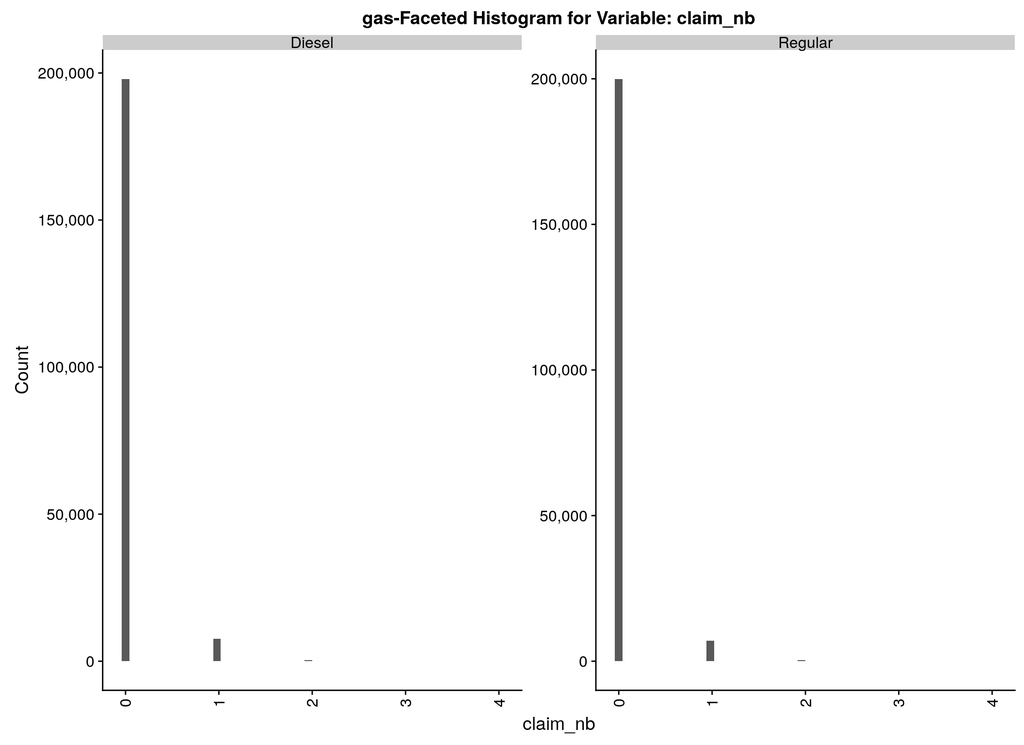

```
## --
## exposure
```

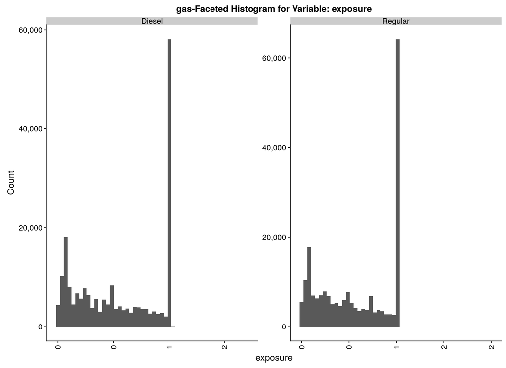

```
## --
## car_age
```

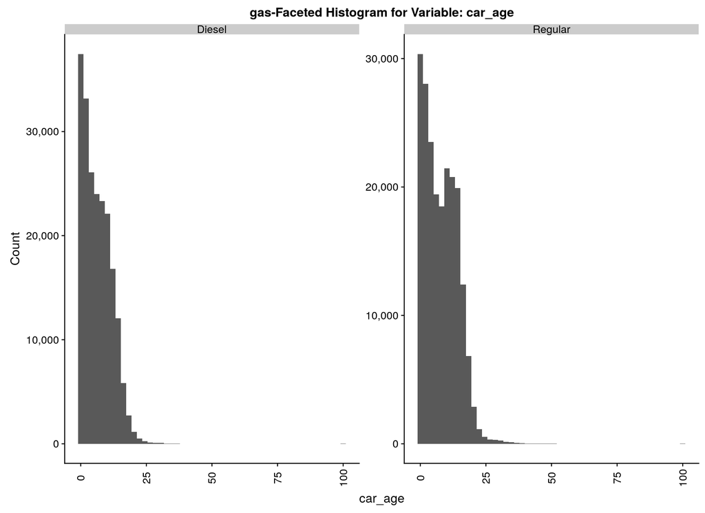

```
## --
## driver_age
```

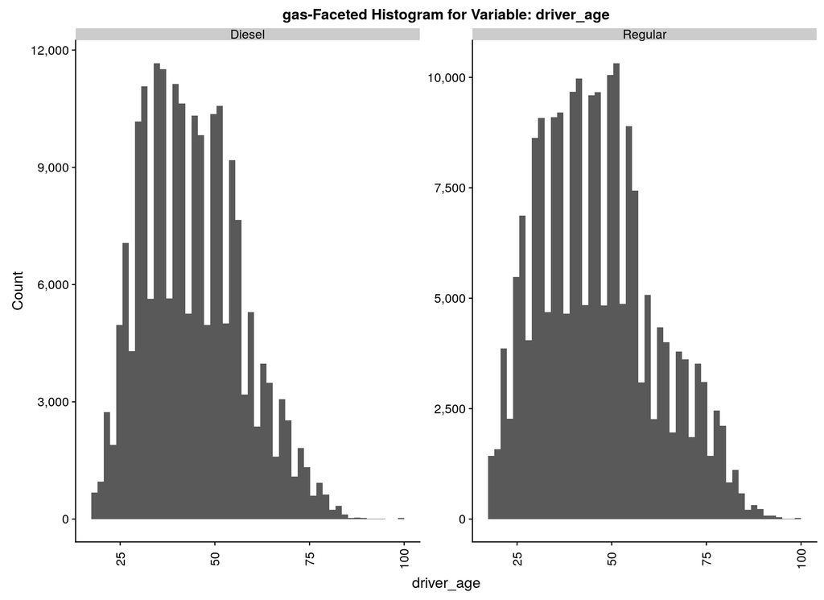

```
## --
## density
```

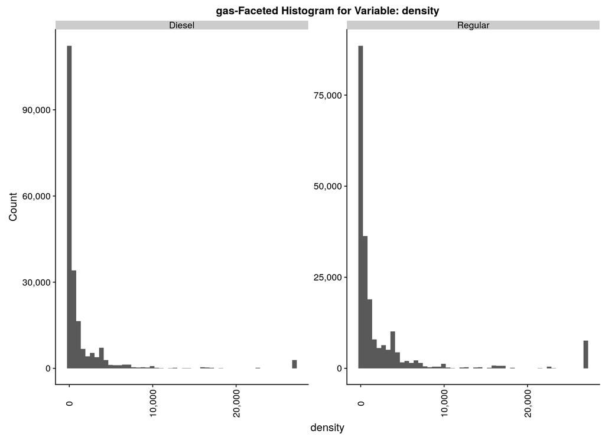

```r
for(plot_varname in numeric_vars) {
    cat("--\n")
    cat(paste0(plot_varname, '\n'))

    filter_formula <- formula(paste0("~ !is.na(", plot_varname, ")"))

    plot_tbl <- data_tbl %>% filter_(filter_formula)

    facet_count <- plot_tbl %>%
        .[[facet_varname]] %>%
        unique %>%
        length %>%
        min(facet_count_max)

    explore_plot <- ggplot(plot_tbl) +
        geom_histogram(aes_string(x = plot_varname), bins = dataexp_hist_bins_count) +
        facet_wrap(facet_formula, scales = 'free') +
        xlab(plot_varname) +
        ylab("Count") +
        scale_x_continuous(labels = comma) +
        scale_y_continuous(labels = comma) +
        ggtitle(paste0(facet_varname, '-Faceted Histogram for Variable: ', plot_varname)) +
        theme(axis.text.x = element_text(angle = 90, vjust = 0.5))

    print(explore_plot)
}
```

### 4.1.3 Categorical Variables

We treat categorical variables like logical variables, faceting the barplots of the different levels of the data.

```
## --
## power
```

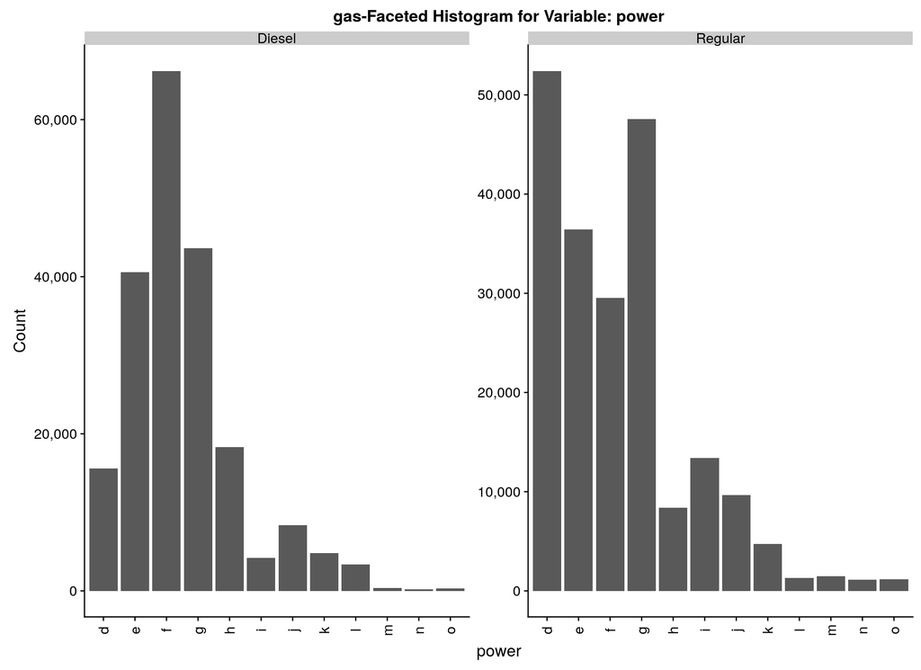

```
## --
## brand
```

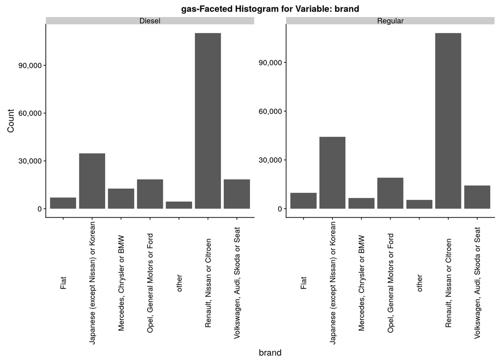

```
## --
## region
```

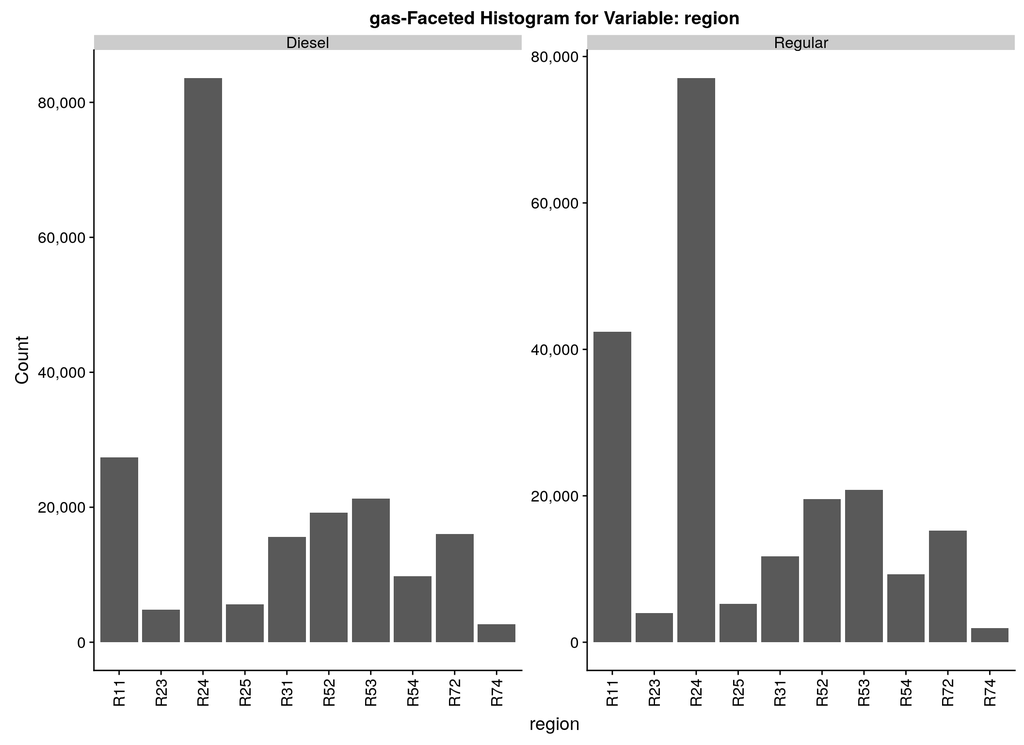

```r
categorical_vars <- categorical_vars[!categorical_vars %in% facet_varname]

for(plot_varname in categorical_vars) {
    cat("--\n")
    cat(paste0(plot_varname, '\n'))

    filter_formula <- formula(paste0("~ !is.na(", plot_varname, ")"))

    plot_tbl <- data_tbl %>% filter_(filter_formula)

    facet_count <- plot_tbl %>%
        .[[facet_varname]] %>%
        unique %>%
        length %>%
        min(facet_count_max)

    explore_plot <- ggplot(plot_tbl) +
        geom_bar(aes_string(x = plot_varname)) +
        facet_wrap(facet_formula, scales = 'free') +
        xlab(plot_varname) +
        ylab("Count") +
        scale_y_continuous(labels = comma) +
        ggtitle(paste0(facet_varname, '-Faceted Histogram for Variable: ', plot_varname)) +
        theme(axis.text.x = element_text(angle = 90, vjust = 0.5))

    plot(explore_plot)
}
```

### 4.1.4 Date/Time Variables

Like the univariate plots, we facet on histograms of the years in the dates.

```r
for(plot_varname in datetime_vars) {
    cat("--\n")
    cat(paste0(plot_varname, '\n'))

    filter_formula <- formula(paste0("~ !is.na(", plot_varname, ")"))

    plot_tbl <- data_tbl %>%
        filter_(filter_formula) %>%
        mutate_(plot_vartmp = plot_varname) %>%
        mutate(plot_var = year(plot_vartmp))

    facet_count <- plot_tbl %>%
        .[[facet_varname]] %>%
        unique %>%
        length %>%
        min(facet_count_max)

    explore_plot <- ggplot(plot_tbl) +
        geom_bar(aes(x = plot_var)) +
        facet_wrap(facet_formula, scales = 'free') +
        xlab(plot_varname) +
        ylab("Count") +
        scale_y_continuous(labels = comma) +
        ggtitle(paste0(facet_varname, '-Faceted Histogram for Variable: ', plot_varname))

    plot(explore_plot)
}
```